# Languedoc_Markdown_06_11

Mélodie

06/11/2020

## Introduction

La première étape de notre projet de TER consiste à analyser trois jeux de données phénotypiques sur des arabidopsis pour comprendre comment des conditions de fort CO2 impactent la quantité de nutriments qu’elles produisent. Vous trouverez ci-après l’analyse du deuxième dataset dont nous disposons qui s’appelle LANGUEDOC.

## Données brutes

Voici les données fournies par nos commanditaires. Nous allons pouvoir leur appliquer plusieurs traitement afin de nous familiariser avec et de visualiser les dynamiques entre les différentes variables observées.

```r
lang <- read.table("LANGUEDOC_phenotypes.csv",sep=";",h=TRUE,na.strings = ".")
head(lang)
```

```
##   genotype Cu_eCo2 Cu_aCo2 Fe_eCo2 Fe_aCo2 Mg_eCo2 Mg_aCo2 Mn_eCo2 Mn_aCo2
## 1    ARR-2    7.61    6.13   55.51   63.80 3058.57 3284.09   69.76   34.51
## 2   ARR-10    8.70    7.34   58.86   68.34 3306.78 3378.36   63.09   47.24
## 3   ARR-11    6.62    7.41   65.25   73.34 3264.47 3370.91   57.15   44.45
## 4   ARR-12    6.78    7.09   70.26   70.93 3512.76 3378.78   62.75   41.61
## 5   ARR-15    7.13    8.61   66.67   85.00 3221.84 3689.61   66.67   51.28
## 6   ARR-17    7.89    6.45   79.82   82.10 3183.60 3665.10   84.12   53.36
##   Na_eCo2 Na_aCo2 Zn_eCo2 Zn_aCo2 C_eCo2 C_aCo2 N_eCo2 N_aCo2 N_change
## 1 2442.78 2252.36   42.00   43.82  35.99  36.42   5.92   6.02       NA
## 2 2289.01 2195.98   45.26   45.86  36.94  36.47   6.05   6.24       NA
## 3 2054.25 2469.35   46.36   44.70  36.58  36.29   5.84   6.14       NA
## 4 1976.73 2679.85   47.73   45.16  36.76  36.81   6.00   6.21       NA
## 5 2006.44 2085.44   49.20   52.00  37.60  34.38   6.44   6.41       NA
## 6 2326.57 2837.67   59.75   53.95  36.96  36.01   6.04   6.15       NA
##   aCN_ratio eCN_ratio eCN_aCN Fe_change Mg_change Mn_change Na_change Zn_change
## 1        NA        NA      NA        NA        NA        NA        NA        NA
## 2        NA        NA      NA        NA        NA        NA        NA        NA
## 3        NA        NA      NA        NA        NA        NA        NA        NA
## 4        NA        NA      NA        NA        NA        NA        NA        NA
## 5        NA        NA      NA        NA        NA        NA        NA        NA
## 6        NA        NA      NA        NA        NA        NA        NA        NA
```

### Suppression des colonnes avec des Na

Dans ce dataset nous avions des lignes pour lesquelles il manquait une observation, nous les avons donc supprimées.

```r
# supression des colonnes inutiles pour l'instant

lang_no_ch <- subset (lang, select = -c(N_change:Zn_change))
lang_clean = lang_no_ch[-c(10,13,109,116,123,131,150,151,179,180,187,189),]
head(lang_clean)
```

```
##   genotype Cu_eCo2 Cu_aCo2 Fe_eCo2 Fe_aCo2 Mg_eCo2 Mg_aCo2 Mn_eCo2 Mn_aCo2
## 1    ARR-2    7.61    6.13   55.51   63.80 3058.57 3284.09   69.76   34.51
## 2   ARR-10    8.70    7.34   58.86   68.34 3306.78 3378.36   63.09   47.24
## 3   ARR-11    6.62    7.41   65.25   73.34 3264.47 3370.91   57.15   44.45
## 4   ARR-12    6.78    7.09   70.26   70.93 3512.76 3378.78   62.75   41.61
## 5   ARR-15    7.13    8.61   66.67   85.00 3221.84 3689.61   66.67   51.28
## 6   ARR-17    7.89    6.45   79.82   82.10 3183.60 3665.10   84.12   53.36
##   Na_eCo2 Na_aCo2 Zn_eCo2 Zn_aCo2 C_eCo2 C_aCo2 N_eCo2 N_aCo2
## 1 2442.78 2252.36   42.00   43.82  35.99  36.42   5.92   6.02
## 2 2289.01 2195.98   45.26   45.86  36.94  36.47   6.05   6.24
## 3 2054.25 2469.35   46.36   44.70  36.58  36.29   5.84   6.14
## 4 1976.73 2679.85   47.73   45.16  36.76  36.81   6.00   6.21
## 5 2006.44 2085.44   49.20   52.00  37.60  34.38   6.44   6.41
## 6 2326.57 2837.67   59.75   53.95  36.96  36.01   6.04   6.15
```

## Identification des outliers

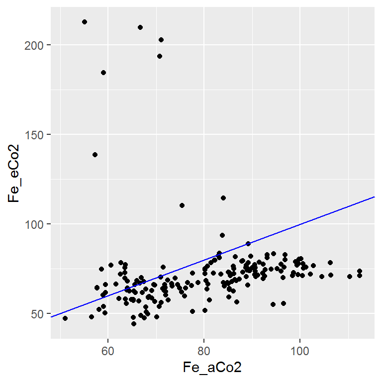

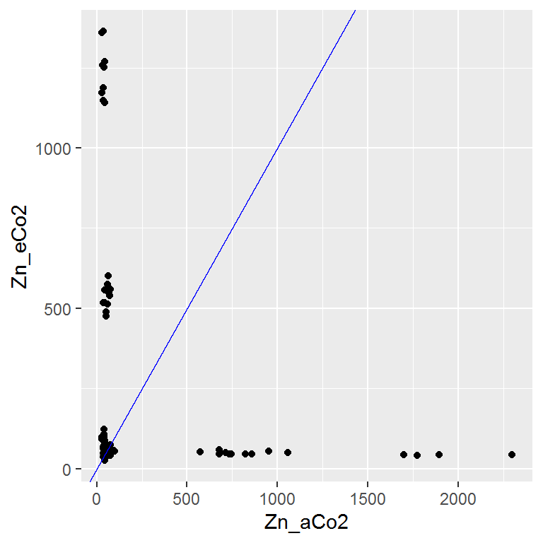

Comme le montrent ces deux Scatter plots,certaines valeurs pour certains éléments sont très singulières, et après discussion avec nos encadrants nous en avons conclu qu’il s’agit d’erreurs de mesures qui ne peuvent pas exister en réalité. Nous allons donc les supprimer.

## Suppression des outliers

```r
lang_no_out <- lang_clean
k= 3
for (i in 2:17) {
  binf <- median(lang_clean[,i]) - k* mad(lang_clean[,i])
  bsup <- median(lang_clean[,i]) + k* mad(lang_clean[,i])
  outlier_idx <- which(lang_no_out[,i] < binf | lang_no_out[,i] > bsup)
    if (length(outlier_idx) == 0) {
      lang_no_out = lang_no_out
    }
    else{
      lang_no_out = lang_no_out[-c(outlier_idx),]
      }
  #print(outlier_idx)
  }
```

```r
library(naniar)
k= 3

lang_no_out_NA <- lang_clean
for (i in 2:17) {
  binf <- median(lang_clean[,i]) - k* mad(lang_clean[,i])
  bsup <- median(lang_clean[,i]) + k* mad(lang_clean[,i])
  outlier_idx <- which(lang_no_out_NA[,i] < binf | lang_no_out_NA[,i] > bsup)
  if (length(outlier_idx) == 0) {
    lang_no_out_NA = lang_no_out_NA
  }
  else{
    lang_no_out_NA[c(outlier_idx),i] =NA
  }
}
```

On passe donc de 200 à 110 plantes, en enlevant les lignes avec des Na et les outliers,

### Calcul des colonnes de variation sans les outliers

Comme nous avons supprimé les lignes contenant des outliers, ils nous faut recalculer les colonnes de variation pour chaque élément, ce qui nous donne ce nouveau DataFrame :

```
##   genotype Cu_eCo2 Cu_aCo2 Fe_eCo2 Fe_aCo2 Mg_eCo2 Mg_aCo2 Mn_eCo2 Mn_aCo2
## 1    ARR-2    7.61    6.13   55.51   63.80 3058.57 3284.09   69.76   34.51
## 2   ARR-10    8.70    7.34   58.86   68.34 3306.78 3378.36   63.09   47.24
## 3   ARR-11    6.62    7.41   65.25   73.34 3264.47 3370.91   57.15   44.45
## 4   ARR-12    6.78    7.09   70.26   70.93 3512.76 3378.78   62.75   41.61
## 5   ARR-15    7.13    8.61   66.67   85.00 3221.84 3689.61   66.67   51.28
## 6   ARR-17    7.89    6.45   79.82   82.10 3183.60 3665.10   84.12   53.36
##   Na_eCo2 Na_aCo2 Zn_eCo2 Zn_aCo2 C_eCo2 C_aCo2 N_eCo2 N_aCo2 N_change
## 1 2442.78 2252.36   42.00   43.82  35.99  36.42   5.92   6.02    -1.66
## 2 2289.01 2195.98   45.26   45.86  36.94  36.47   6.05   6.24    -3.04
## 3 2054.25 2469.35   46.36   44.70  36.58  36.29   5.84   6.14    -4.89
## 4 1976.73 2679.85   47.73   45.16  36.76  36.81   6.00   6.21    -3.38
## 5 2006.44 2085.44   49.20   52.00  37.60  34.38   6.44   6.41     0.47
## 6 2326.57 2837.67   59.75   53.95  36.96  36.01   6.04   6.15    -1.79
##   Fe_change Mg_change Mn_change Na_change Zn_change C_change Cu_change
## 1    -12.99     -6.87    102.14      8.45     -4.15    -1.18     24.14
## 2    -13.87     -2.12     33.55      4.24     -1.31     1.29     18.53
## 3    -11.03     -3.16     28.57    -16.81      3.71     0.80    -10.66
## 4     -0.94      3.97     50.81    -26.24      5.69    -0.14     -4.37
## 5    -21.56    -12.68     30.01     -3.79     -5.38     9.37    -17.19
## 6     -2.78    -13.14     57.65    -18.01     10.75     2.64     22.33
```

## Première Visualisation : Variation moyenne des mesures entre le aCO2 et le eCO2

Nous avons ici voulu reproduire une visualisation qui avait été faite dans le cas du riz pour montrer la variation de chaque élément quand la plante est en condition de fort CO2 et quand elle est en condition de CO2 ambiant

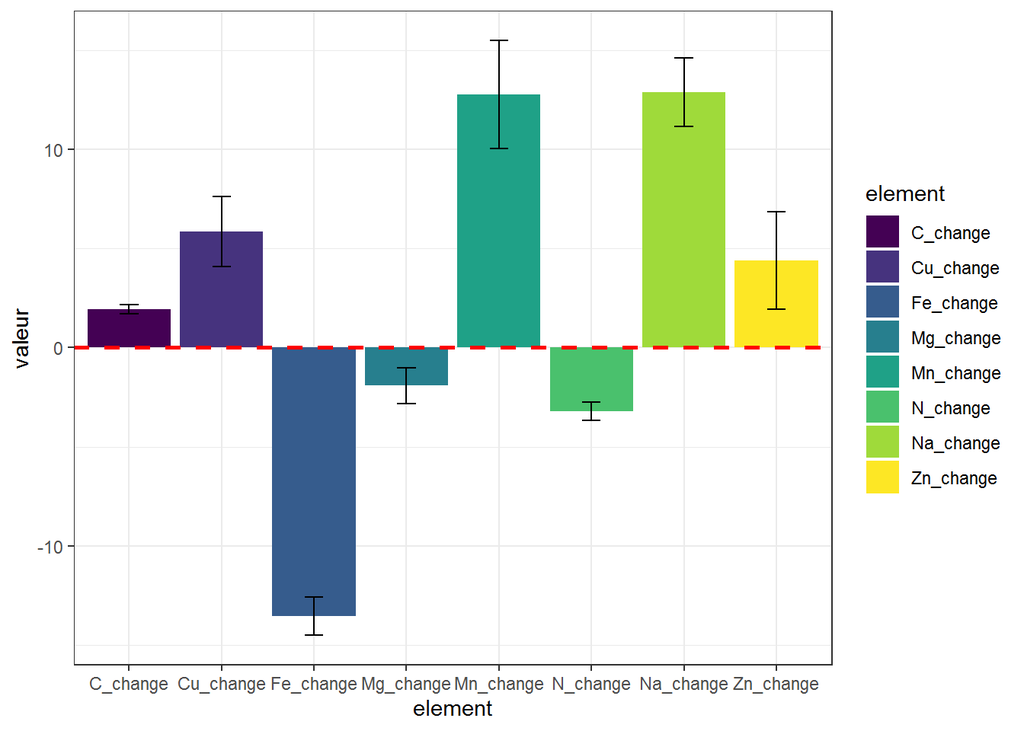

```r
ggplot(lang_chl, aes(element, valeur, fill = element))+
  stat_summary(fun = mean, geom = "bar") +
  stat_summary(fun.data = mean_se, geom = "errorbar", width = 0.2)+
  geom_hline(yintercept = 0, color = "red", linetype = "dashed", size = 1) +
  scale_fill_viridis_d() +
  scale_color_viridis_d() +
  theme_bw()
```

Observations :

## Scatter plots

Afin de visualiser d’une autre façon si il y a une perte de certains éléments quand la plante est en condition de fort CO2, nous avons créé des scatter plots.

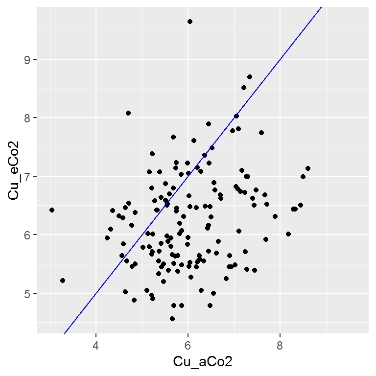

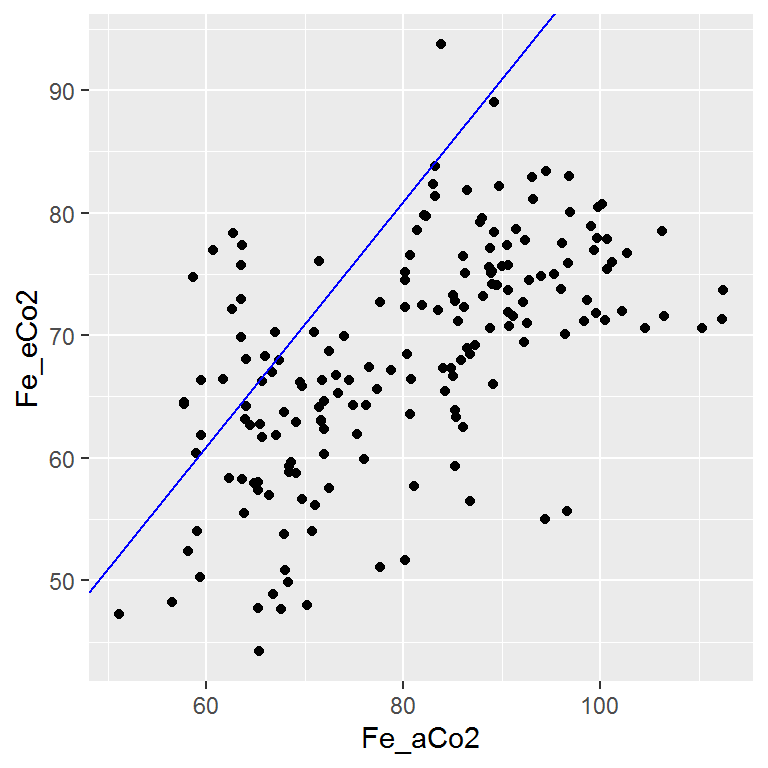

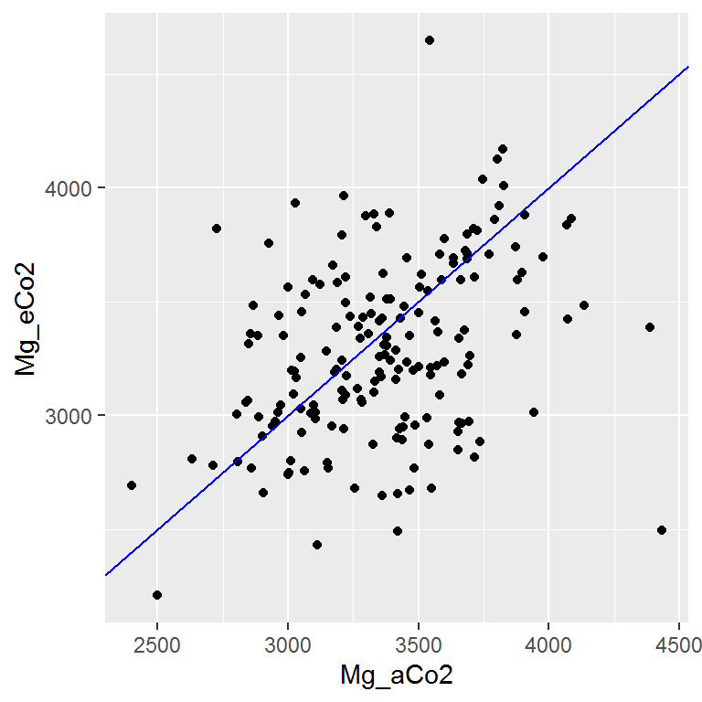

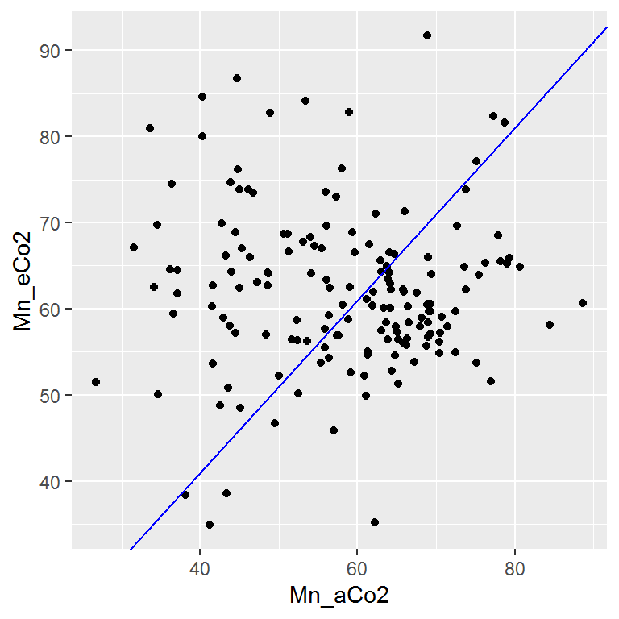

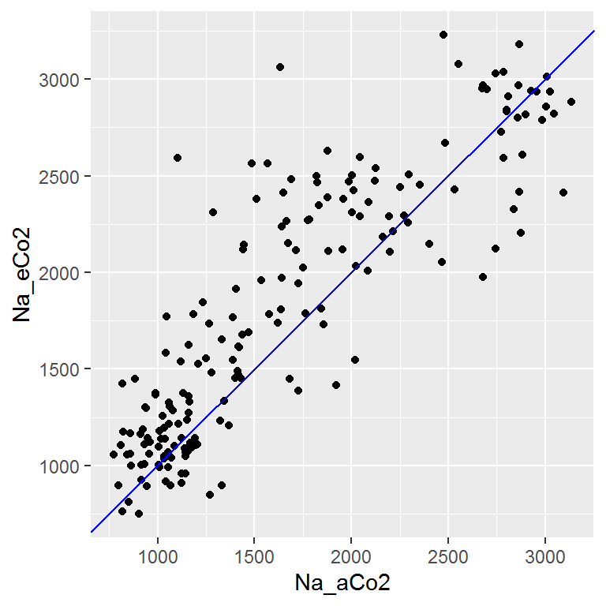

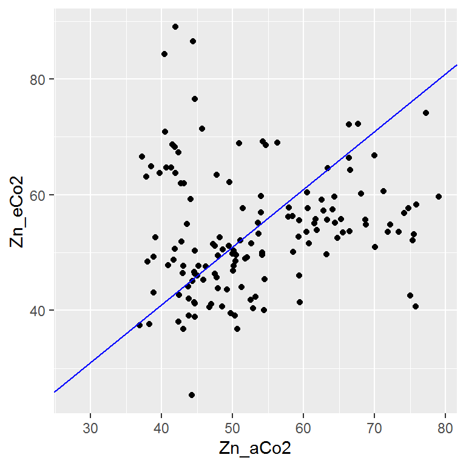

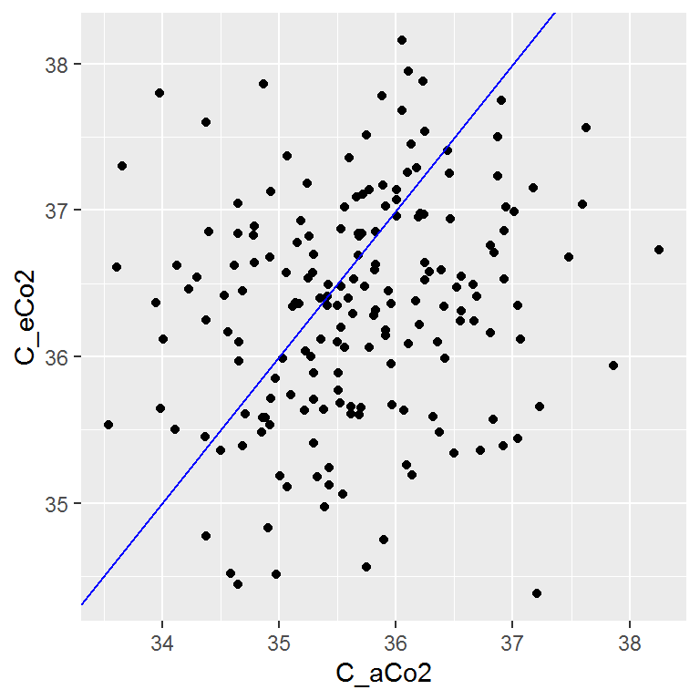

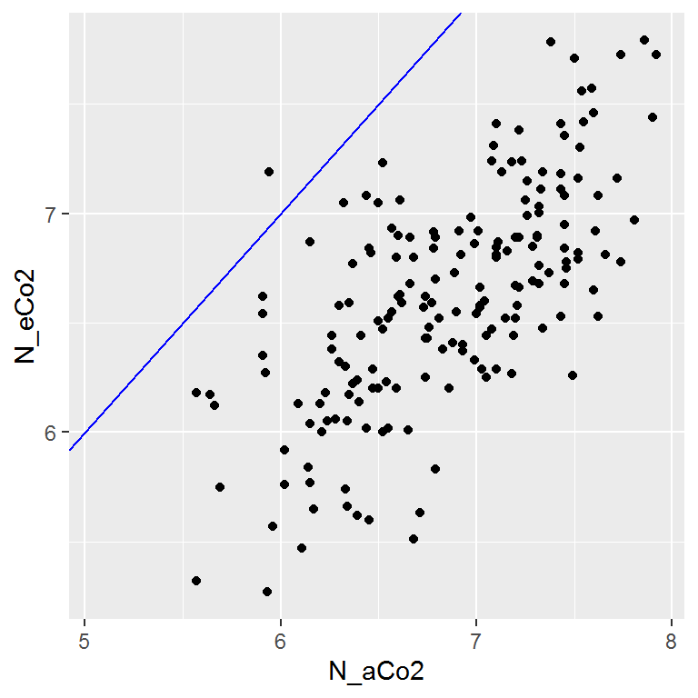

```r
i = 2
while (i < 17) {
  print(
    ggplot(data= lang_no_out_NA, aes(x =lang_no_out_NA[,i+1], y = lang_no_out_NA[,i]))+
    geom_point()+
    xlab(colnames(lang)[i+1]) + ylab(colnames(lang)[i])+
    geom_abline(slope = 1, intercept = 1,col="blue")
  )

i = i + 2}
```

## Distribution des données : Histogrammes et Violin plots

### Violin plots

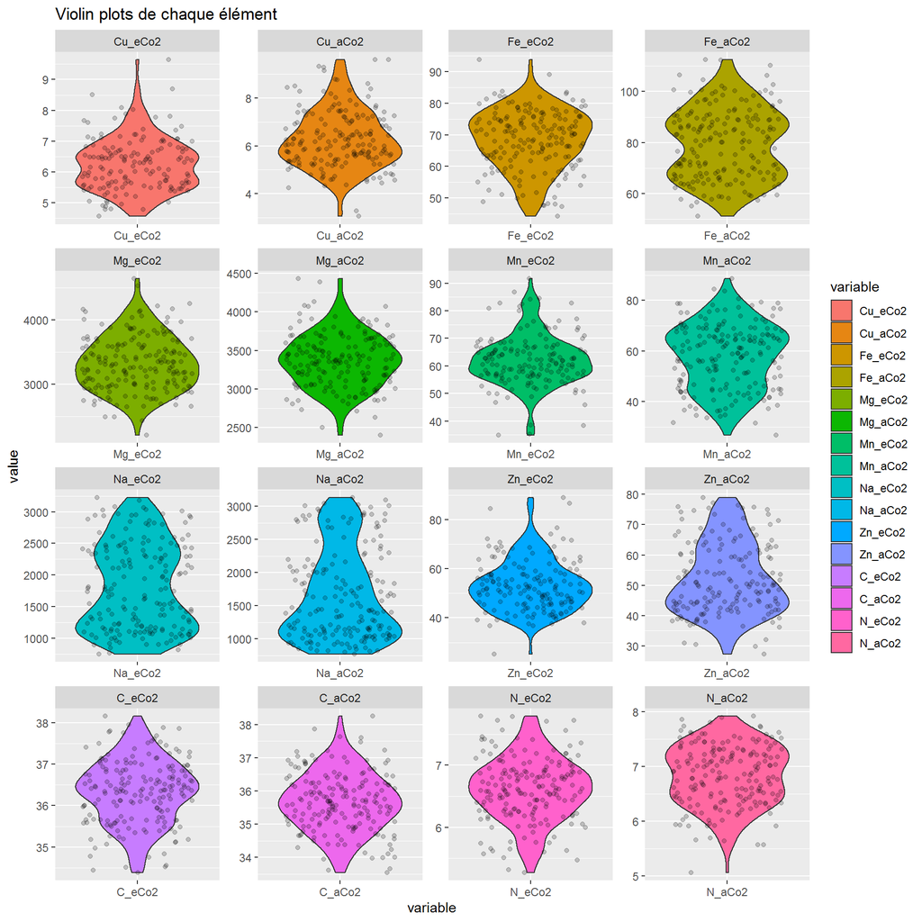

### Histogrammes

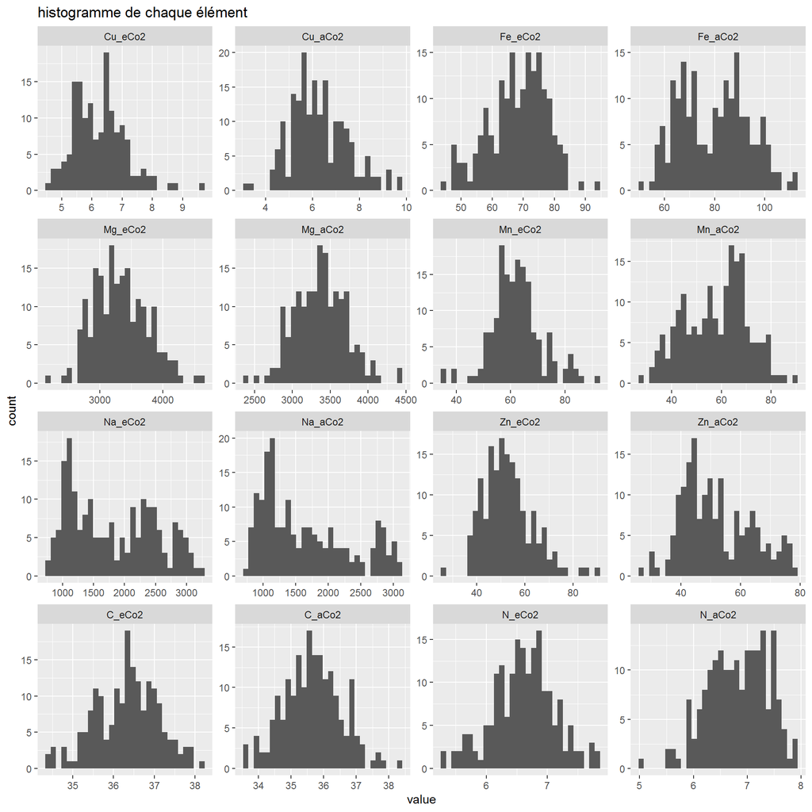

Après ces deux visualisations nous pouvons remarquer que les distributions ont l’air pour la plupart normales mais que des doutes quand à leur normalité persistent.

## Tests de normalité : Test de Shapiro

Dans le but de choisir des tests sur la moyenne et sur la variance adaptés à nos données, nous avons commencé par réaliser un test de normalité, ici le test de Shapiro.

Voici les p-values pour la distribution de chaque élément :

```
## [1] "Test de Shapiro entre les données Cu_eCo2"
## [1] 0.001293694
## [1] "Test de Shapiro entre les données Cu_aCo2"
## [1] 0.008807213
## [1] "Test de Shapiro entre les données Fe_eCo2"
## [1] 0.01996014
## [1] "Test de Shapiro entre les données Fe_aCo2"
## [1] 0.001042923
## [1] "Test de Shapiro entre les données Mg_eCo2"
## [1] 0.2719628
## [1] "Test de Shapiro entre les données Mg_aCo2"
## [1] 0.8353182
## [1] "Test de Shapiro entre les données Mn_eCo2"
## [1] 0.001322941
## [1] "Test de Shapiro entre les données Mn_aCo2"
```

[output cut: 17 more lines]

### Test de significativité sur les moyennes : Wilcoxon

Ici on a choisi un test de Wilcoxon (car on ne respecte pas les pré-requis pour un test paramétrique pour toutes nos variables) pour des valeurs paired, car la mesure en Co2 ambiant et élevé sont réalisées sur les mêmes génotypes. Vous trouverez ci dessous des violin plots deux à deux et la p-value de chaque paire avec le test de Wilcoxon.

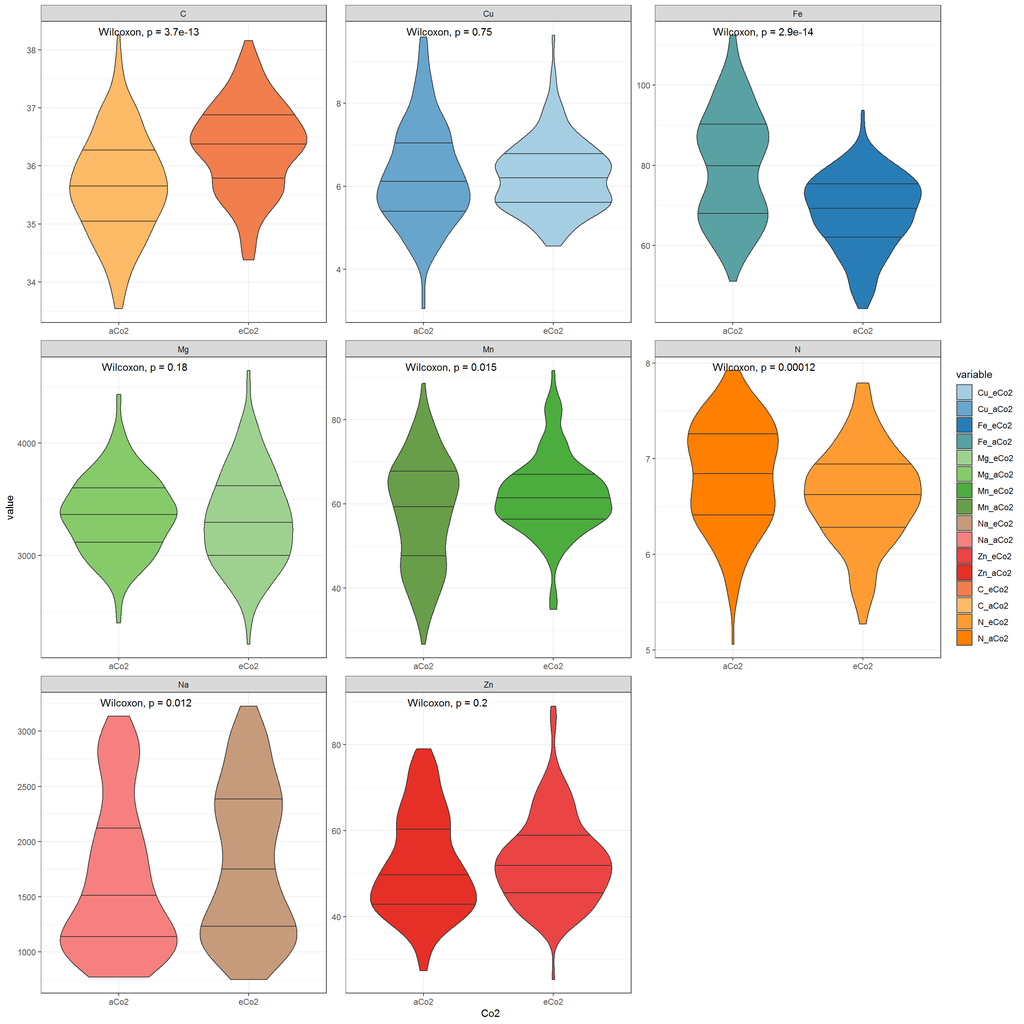

```r
library(ggplot2)
library(RColorBrewer)
library(ggpubr)

lang_long = melt(lang_no_out_no_ch)
lang_long$element = stringr::str_split_fixed(lang_long$variable, "_",2)[,1]
lang_long$Co2 = stringr::str_split_fixed(lang_long$variable, "_",2)[,2]

nb.cols <- 16
mycolors <- colorRampPalette(brewer.pal(8, "Paired"))(nb.cols)

p <- ggplot(data = lang_long, aes(x = Co2, y = value)) +
  geom_violin(aes(fill = variable), draw_quantiles = c(0.25,0.5,0.75)) +
  facet_wrap( ~ element, scales = "free") +
  scale_fill_manual(values = mycolors)
  #stat_compare_means(paired = TRUE, method = "wilcox", rm.na=TRUE)
p + stat_compare_means() + theme_bw()
```

### Autre visualisation du résultat du test de Wilcoxon

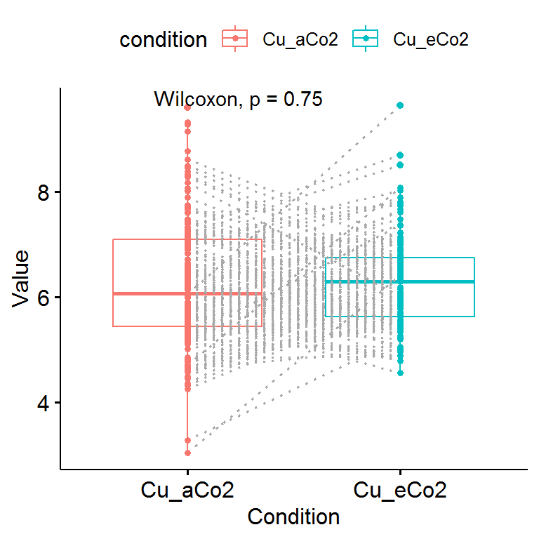

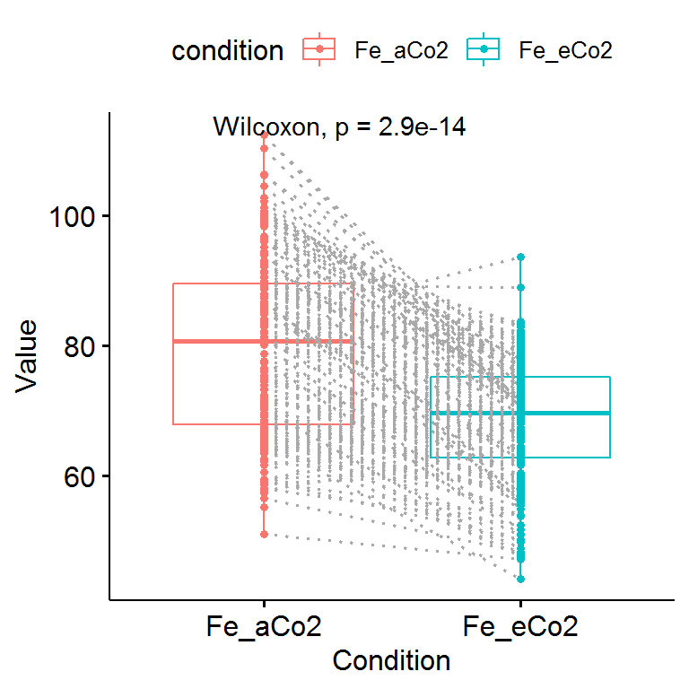

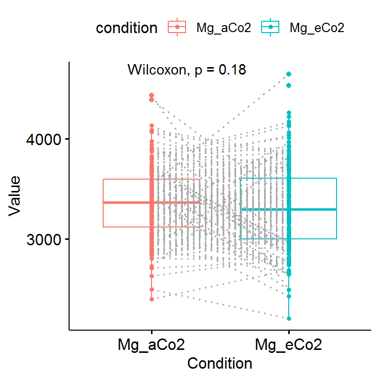

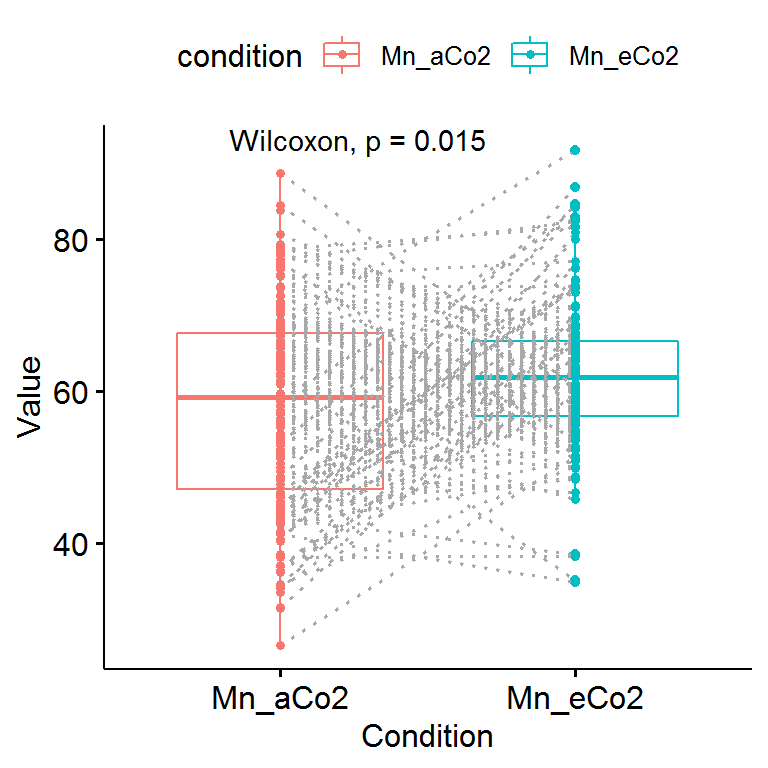

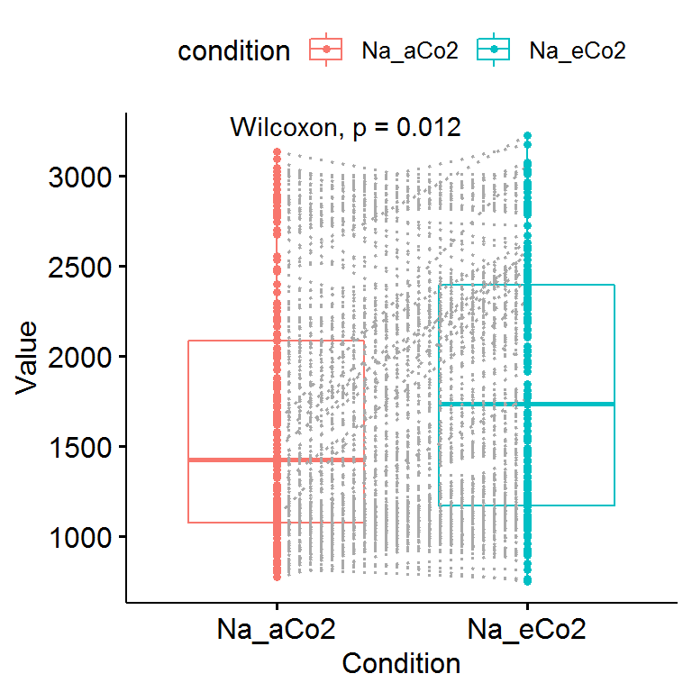

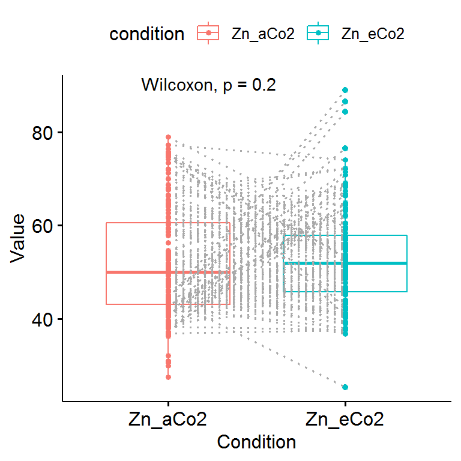

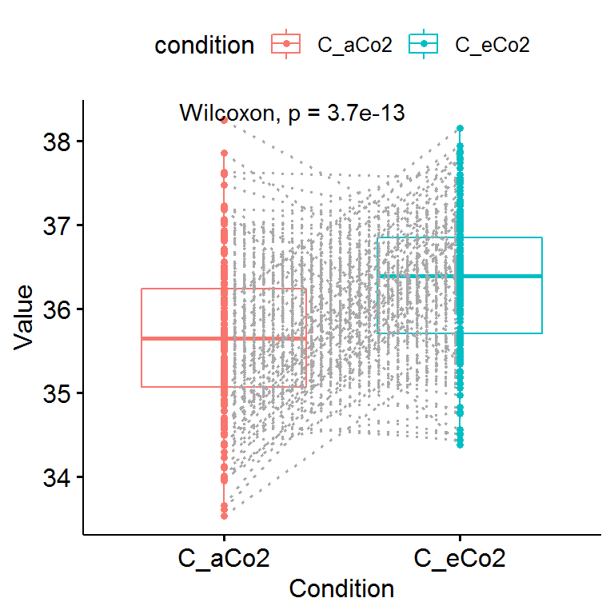

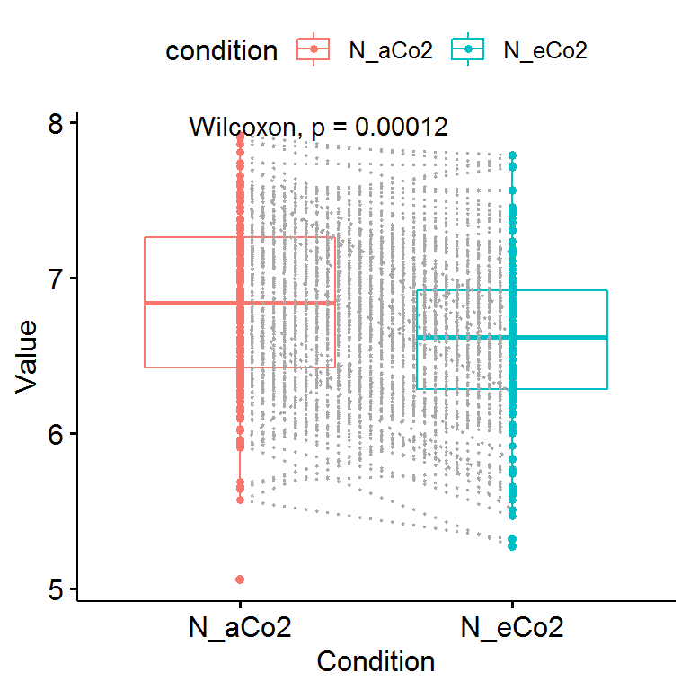

```r
i=2
while (i < 17) {
  plot_paired <- ggpaired(lang_no_out_NA, cond1 = names(lang_no_out_NA[i+1]) , cond2 = names(lang_no_out_NA[i]),
           line.color = "dark gray", line.size = 0.6, color = "condition",
           width = 0.7, linetype = "dotted" ,
           palette = "aas")+
    stat_compare_means()
  print(plot_paired)
  i = i+2
}
```

### Test de significativité sur les moyennes pour les répartitions normales : Student

Pour avoir la certitude que les moyennes sont significativement différentes, nous avons fait un test de Student sur les éléments dont la répartition est normale.

```
## [1] "Test de Student entre les données C_aCo2 et C_eCo2"
```

```
## [1] "p-value =  7.6373518230401e-15"
```

```
## [1] "Test de Student entre les données Mg_aCo2 et Mg_eCo2"
```

```
## [1] "p-value =  0.00780185017971631"
```

Ici, on observe que tous les éléments de distribution normales ont une moyenne significativement différente.

Nous sommes donc encore plus assurés que les moyennes sont significativement différentes

### Test de significativité sur les variances pour les répartitions non normales : Levene

```
## [1] "Test de Levene entre les données Cu_eCo2 et Cu_aCo2"
## [1] "p-value =  0.000245477825725948"
## [1] "Test de Levene entre les données Fe_eCo2 et Fe_aCo2"
## [1] "p-value =  3.95505868617263e-10"
## [1] "Test de Levene entre les données Mg_eCo2 et Mg_aCo2"
## [1] "p-value =  0.00285865764969549"
## [1] "Test de Levene entre les données Mn_eCo2 et Mn_aCo2"
## [1] "p-value =  3.13176016510055e-07"
## [1] "Test de Levene entre les données Na_eCo2 et Na_aCo2"
## [1] "p-value =  0.27308394575234"
## [1] "Test de Levene entre les données Zn_eCo2 et Zn_aCo2"
## [1] "p-value =  0.0351234225472034"
## [1] "Test de Levene entre les données C_eCo2 et C_aCo2"
## [1] "p-value =  0.0955373214558625"
## [1] "Test de Levene entre les données N_eCo2 et N_aCo2"
## [1] "p-value =  0.0446086701445524"
```

```r
#sapply(reg_no_out_NA, var(na.rm=TRUE))
sapply(lang_no_out_NA, function(x)  var=var(x,na.rm=TRUE))
```

```
##     genotype      Cu_eCo2      Cu_aCo2      Fe_eCo2      Fe_aCo2      Mg_eCo2
##           NA 7.219486e-01 1.440319e+00 8.597236e+01 1.871342e+02 1.825947e+05
##      Mg_aCo2      Mn_eCo2      Mn_aCo2      Na_eCo2      Na_aCo2      Zn_eCo2
## 1.185579e+05 8.674563e+01 1.639702e+02 4.629908e+05 4.566351e+05 1.057962e+02
##      Zn_aCo2       C_eCo2       C_aCo2       N_eCo2       N_aCo2
## 1.356466e+02 5.974054e-01 7.737649e-01 2.548004e-01 3.025656e-01
```

### Test de significativité sur les variances pour les répartitions normales : Fisher

```
## [1] "Test de Fisher entre les données C_aCo2 et C_eCo2"
```

```
## [1] "p-value =  0.0793707789275628"
```

```
## [1] "Test de Student entre les données Mg_aCo2 et Mg_eCo2"
```

```
## [1] "p-value =  0.00379467267216382"
```